# Practical Machine Learning Course Project

Renan Almeida Baqui

02/11/2021

**Practical Machine Learning by Johns Hopkins University**

**Course Project**

**Background**

Using devices such as Jawbone Up, Nike FuelBand, and Fitbit it is now possible to collect a large amount of data about personal activity relatively inexpensively. These type of devices are part of the quantified self movement – a group of enthusiasts who take measurements about themselves regularly to improve their health, to find patterns in their behavior, or because they are tech geeks. One thing that people regularly do is quantify how much of a particular activity they do, but they rarely quantify how well they do it. In this project, your goal will be to use data from accelerometers on the belt, forearm, arm, and dumbell of 6 participants. They were asked to perform barbell lifts correctly and incorrectly in 5 different ways. More information is available from the website here: http://groupware.les.inf.puc-rio.br/har (see the section on the Weight Lifting Exercise Dataset).

**Data**

The training data for this project are available here:

https://d396qusza40orc.cloudfront.net/predmachlearn/pml-training.csv

The test data are available here:

https://d396qusza40orc.cloudfront.net/predmachlearn/pml-testing.csv

The data for this project come from this source: http://groupware.les.inf.puc-rio.br/har. If you use the document you create for this class for any purpose please cite them as they have been very generous in allowing their data to be used for this kind of assignment.

**What you should submit**

The goal of your project is to predict the manner in which they did the exercise. This is the “classe” variable in the training set. You may use any of the other variables to predict with. You should create a report describing how you built your model, how you used cross validation, what you think the expected out of sample error is, and why you made the choices you did. You will also use your prediction model to predict 20 different test cases.

**The Project**

**Libraries**

Loading the R packages and libraries

```r
library(caret)
```

```r
library(knitr)
library(rpart)
library(rpart.plot)
library(rattle)
library(randomForest)
set.seed(13343)
```

**Downloading the Data**

Extracting the two data sets from the provided URLs

```r
trainingData <- read.csv('https://d396qusza40orc.cloudfront.net/predmachlearn/pml-training.csv',header=T)
testingData <- read.csv('https://d396qusza40orc.cloudfront.net/predmachlearn/pml-testing.csv',header=T)
```

Creating two subsets within the training data set: *train* (75%) and *cross validation* (25%)

```r
inTrain  <- createDataPartition(trainingData$classe, p=0.75, list=FALSE)
TrainSet <- trainingData[inTrain, ]
CrossValSet  <- trainingData[-inTrain, ]
dim(TrainSet)
```

```
## [1] 14718   160
```

```r
dim(CrossValSet)
```

```
## [1] 4904  160
```

**Pre-processing**

Verifying and exploring the training data set

Removing nearly zero variance (NZV) variables from both sets

```r
NZV <- nearZeroVar(TrainSet)
TrainSet <- TrainSet[, -NZV]
CrossValSet  <- CrossValSet[, -NZV]
dim(TrainSet)
```

```
## [1] 14718   105
```

```r
dim(CrossValSet)
```

```
## [1] 4904  105
```

Removing NA variables (more than 70% of NA in the variable)

```r
AllNA    <- sapply(TrainSet, function(x) mean(is.na(x))) > 0.7
TrainSet <- TrainSet[, AllNA==FALSE]
CrossValSet  <- CrossValSet[, AllNA==FALSE]
dim(TrainSet)
```

```
## [1] 14718    59
```

```r
dim(CrossValSet)
```

```
## [1] 4904   59
```

Removing unnecessary qualitative variables (columns 1 to 7)

```r
TrainSet <- TrainSet[, -(1:7)]
CrossValSet  <- CrossValSet[, -(1:7)]
dim(TrainSet)
```

```
## [1] 14718    52
```

```r
dim(CrossValSet)
```

```
## [1] 4904   52
```

**Training the Machine Learning Models**

*Decision Tree Model*

Model fit

[figure not shown]

```r
set.seed(13343)
modFitDecTree <- rpart(classe ~ ., data=TrainSet, method="class")
fancyRpartPlot(modFitDecTree)
```

Prediction and Confusion Matrix on Cross Validation data set

```r
predictDecTree <- predict(modFitDecTree, newdata=CrossValSet, type="class")
confMatDecTree <- confusionMatrix(predictDecTree, as.factor(CrossValSet$classe))
confMatDecTree
```

```
## Confusion Matrix and Statistics
##
##           Reference
## Prediction    A    B    C    D    E
##          A 1229  177   24   53   62
##          B   37  503   41   63   28
##          C   22   63  606  124  128
##          D   91  143  164  505  119
##          E   16   63   20   59  564
##
## Overall Statistics
##
##                Accuracy : 0.6947
##                  95% CI : (0.6816, 0.7076)
##     No Information Rate : 0.2845
##     P-Value [Acc > NIR] : < 2.2e-16
##
##                   Kappa : 0.6132
##
##  Mcnemar's Test P-Value : < 2.2e-16
##
## Statistics by Class:
##
##                      Class: A Class: B Class: C Class: D Class: E
## Sensitivity            0.8810   0.5300   0.7088   0.6281   0.6260
## Specificity            0.9099   0.9573   0.9168   0.8739   0.9605
## Pos Pred Value         0.7955   0.7485   0.6426   0.4941   0.7812
## Neg Pred Value         0.9506   0.8946   0.9371   0.9230   0.9194
## Prevalence             0.2845   0.1935   0.1743   0.1639   0.1837
## Detection Rate         0.2506   0.1026   0.1236   0.1030   0.1150
## Detection Prevalence   0.3150   0.1370   0.1923   0.2084   0.1472
## Balanced Accuracy      0.8955   0.7437   0.8128   0.7510   0.7933
```

Plot and model accuracy

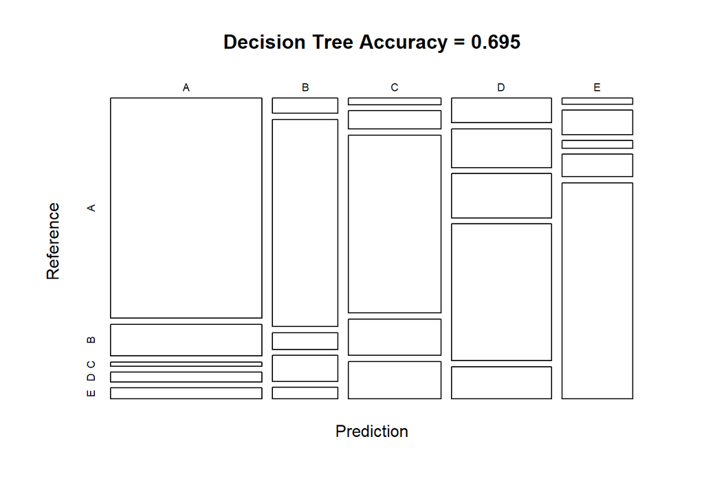

```r
plot(confMatDecTree$table, col = confMatDecTree$byClass,
     main = paste("Decision Tree Accuracy =",
                  round(confMatDecTree$overall['Accuracy'], 3)))
```

Expected out of sample error for Decision Tree: 1 - 0.695 = 0.305

*Random Forest*

Model fit

```r
controlRF <- trainControl(method="cv", number=3, verboseIter=FALSE)
modFitRandForest <- train(classe ~ ., data=TrainSet, method="rf",
                          trControl=controlRF)
modFitRandForest$finalModel
```

```
##
## Call:
##  randomForest(x = x, y = y, mtry = param$mtry)
##                Type of random forest: classification
##                      Number of trees: 500
## No. of variables tried at each split: 26
##
##         OOB estimate of  error rate: 0.61%
## Confusion matrix:
##      A    B    C    D    E class.error
## A 4180    3    1    0    1 0.001194743
## B   16 2824    7    0    1 0.008426966
## C    0   11 2547    9    0 0.007791196
## D    0    0   29 2379    4 0.013681592
## E    0    0    4    4 2698 0.002956393
```

Prediction and Confusion Matrix on Cross Validation data set

```r
predictRandForest <- predict(modFitRandForest, newdata=CrossValSet)
confMatRandForest <- confusionMatrix(predictRandForest, as.factor(CrossValSet$classe))
confMatRandForest
```

```
## Confusion Matrix and Statistics
##
##           Reference
## Prediction    A    B    C    D    E
##          A 1392   14    0    0    0
##          B    3  932    9    0    0
##          C    0    3  846    5    1
##          D    0    0    0  799    2
##          E    0    0    0    0  898
##
## Overall Statistics
##
##                Accuracy : 0.9925
##                  95% CI : (0.9896, 0.9947)
##     No Information Rate : 0.2845
##     P-Value [Acc > NIR] : < 2.2e-16
##
##                   Kappa : 0.9905
##
##  Mcnemar's Test P-Value : NA
##
## Statistics by Class:
##
##                      Class: A Class: B Class: C Class: D Class: E
## Sensitivity            0.9978   0.9821   0.9895   0.9938   0.9967
## Specificity            0.9960   0.9970   0.9978   0.9995   1.0000
## Pos Pred Value         0.9900   0.9873   0.9895   0.9975   1.0000
## Neg Pred Value         0.9991   0.9957   0.9978   0.9988   0.9993
## Prevalence             0.2845   0.1935   0.1743   0.1639   0.1837
## Detection Rate         0.2838   0.1900   0.1725   0.1629   0.1831
## Detection Prevalence   0.2867   0.1925   0.1743   0.1633   0.1831
## Balanced Accuracy      0.9969   0.9895   0.9936   0.9966   0.9983
```

Plot and model accuracy

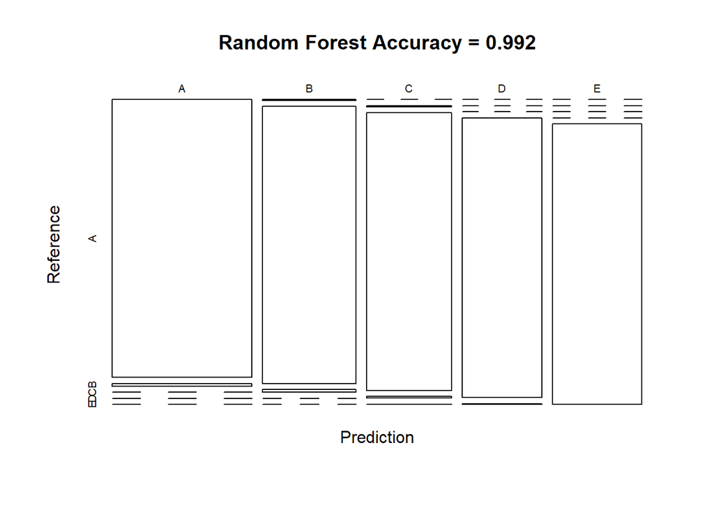

```r
plot(confMatRandForest$table, col = confMatRandForest$byClass,
     main = paste("Random Forest Accuracy =",
                  round(confMatRandForest$overall['Accuracy'], 3)))
```

Expected out of sample error for Random Forest: 1 - 0.992 = 0.008

*Generalized Boosted Model (GBM)*

Model fit

```r
set.seed(13343)
controlGBM <- trainControl(method = "repeatedcv", number = 5, repeats = 1)
modFitGBM  <- train(classe ~ ., data=TrainSet, method = "gbm",
                    trControl = controlGBM, verbose = FALSE)
modFitGBM$finalModel
```

```
## A gradient boosted model with multinomial loss function.
## 150 iterations were performed.
## There were 51 predictors of which 51 had non-zero influence.
```

Prediction and Confusion Matrix on Cross Validation data set

```r
predictGBM <- predict(modFitGBM, newdata=CrossValSet)
confMatGBM <- confusionMatrix(predictGBM, as.factor(CrossValSet$classe))
confMatGBM
```

```
## Confusion Matrix and Statistics
##
##           Reference
## Prediction    A    B    C    D    E
##          A 1363   33    0    0    1
##          B   24  886   29    3   11
##          C    4   26  814   29    6
##          D    2    3    9  762    5
##          E    2    1    3   10  878
##
## Overall Statistics
##
##                Accuracy : 0.959
##                  95% CI : (0.9531, 0.9644)
##     No Information Rate : 0.2845
##     P-Value [Acc > NIR] : < 2.2e-16
##
##                   Kappa : 0.9482
##
##  Mcnemar's Test P-Value : 0.001055
##
## Statistics by Class:
##
##                      Class: A Class: B Class: C Class: D Class: E
## Sensitivity            0.9771   0.9336   0.9520   0.9478   0.9745
## Specificity            0.9903   0.9831   0.9839   0.9954   0.9960
## Pos Pred Value         0.9757   0.9297   0.9261   0.9757   0.9821
## Neg Pred Value         0.9909   0.9841   0.9898   0.9898   0.9943
## Prevalence             0.2845   0.1935   0.1743   0.1639   0.1837
## Detection Rate         0.2779   0.1807   0.1660   0.1554   0.1790
## Detection Prevalence   0.2849   0.1943   0.1792   0.1593   0.1823
## Balanced Accuracy      0.9837   0.9583   0.9680   0.9716   0.9852
```

Plot and model accuracy

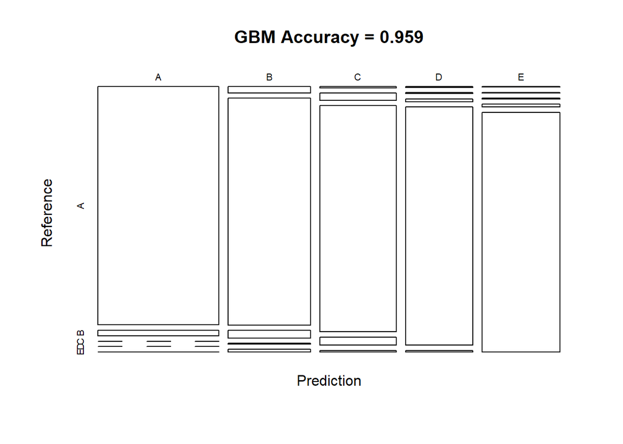

```r
plot(confMatGBM$table, col = confMatGBM$byClass,
     main = paste("GBM Accuracy =", round(confMatGBM$overall['Accuracy'], 3)))
```

Expected out of sample error for the Generalized Boosted Model: 1 - 0.959 = 0.041

**Prediction on Test Cases**

Since the *Random Forest Model* provided the best accuracy (and less expected out of sample error) among the three tested models earlier, this is the one that is going to be chosen for my final prediction

Final prediction on testing data (Course Project Prediction Quiz)

```r
predictQuiz <- predict(modFitRandForest, newdata=testingData)
predictQuiz
```

```
##  [1] B A B A A E D B A A B C B A E E A B B B
## Levels: A B C D E
```